# P4_Kyuri

Kyuri Park

September 17, 2022

First, load the packages:

```r
library(ISLR)
library(MASS)
library(tidyverse)
```

# Regression in R

## 0. Check the data

```r
glimpse(Boston)
```

```
Rows: 506
Columns: 14
$ crim    <dbl> 0.00632, 0.02731, 0.02729, 0.03237, 0.06905, 0.02985, 0.08829,…
$ zn      <dbl> 18.0, 0.0, 0.0, 0.0, 0.0, 0.0, 12.5, 12.5, 12.5, 12.5, 12.5, 1…
$ indus   <dbl> 2.31, 7.07, 7.07, 2.18, 2.18, 2.18, 7.87, 7.87, 7.87, 7.87, 7.…
$ chas    <int> 0, 0, 0, 0, 0, 0, 0, 0, 0, 0, 0, 0, 0, 0, 0, 0, 0, 0, 0, 0, 0,…
$ nox     <dbl> 0.538, 0.469, 0.469, 0.458, 0.458, 0.458, 0.524, 0.524, 0.524,…
$ rm      <dbl> 6.575, 6.421, 7.185, 6.998, 7.147, 6.430, 6.012, 6.172, 5.631,…
$ age     <dbl> 65.2, 78.9, 61.1, 45.8, 54.2, 58.7, 66.6, 96.1, 100.0, 85.9, 9…
$ dis     <dbl> 4.0900, 4.9671, 4.9671, 6.0622, 6.0622, 6.0622, 5.5605, 5.9505…
$ rad     <int> 1, 2, 2, 3, 3, 3, 5, 5, 5, 5, 5, 5, 5, 4, 4, 4, 4, 4, 4, 4, 4,…
$ tax     <dbl> 296, 242, 242, 222, 222, 222, 311, 311, 311, 311, 311, 311, 31…
$ ptratio <dbl> 15.3, 17.8, 17.8, 18.7, 18.7, 18.7, 15.2, 15.2, 15.2, 15.2, 15…
$ black   <dbl> 396.90, 396.90, 392.83, 394.63, 396.90, 394.12, 395.60, 396.90…
$ lstat   <dbl> 4.98, 9.14, 4.03, 2.94, 5.33, 5.21, 12.43, 19.15, 29.93, 17.10…
$ medv    <dbl> 24.0, 21.6, 34.7, 33.4, 36.2, 28.7, 22.9, 27.1, 16.5, 18.9, 15…
```

## 1. Create a linear model object called `lm_ses` using the formula `medv ~ lstat` and the `Boston` dataset.

```r
lm_ses <- lm(formula = medv ~ lstat, data = Boston)
```

## 2. Use the function `coef()` to extract the intercept and slope from the `lm_ses` object. Interpret the slope coefficient.

Interpretation:  
The intercept ($\beta_0$) is 34.5, which means that the average median value of home is $34.5k when `lstate = 0`. $\beta_1$ is -0.95 meaning that the median home value (`medv`) decreases by 0.95 as one unit increase in the lower status (`lstat`).

```r
coef(lm_ses)
```

```
(Intercept)       lstat
 34.5538409  -0.9500494
```

## 3. Use `summary()` to get a summary of the `lm_ses` object. What do you see? You can use the help file `?summary.lm`.

```r
summary(lm_ses)
```

```
Call:
lm(formula = medv ~ lstat, data = Boston)

Residuals:
    Min      1Q  Median      3Q     Max
-15.168  -3.990  -1.318   2.034  24.500

Coefficients:
            Estimate Std. Error t value Pr(>|t|)
(Intercept) 34.55384    0.56263   61.41   <2e-16 ***
lstat       -0.95005    0.03873  -24.53   <2e-16 ***
---
Signif. codes:  0 '***' 0.001 '**' 0.01 '*' 0.05 '.' 0.1 ' ' 1

Residual standard error: 6.216 on 504 degrees of freedom
Multiple R-squared:  0.5441,    Adjusted R-squared:  0.5432
F-statistic: 601.6 on 1 and 504 DF,  p-value: < 2.2e-16
```

## 4. Save the predicted y values to a variable called `y_pred`.

```r
y_pred <- predict(lm_ses)
```

## 5. Create a scatter plot with `y_pred` mapped to the x position and the true y value (`Boston$medv`) mapped to the y value. What do you see? What would this plot look like if the fit were perfect?

If the fit was perfect, then they would form a perfect diagonal.

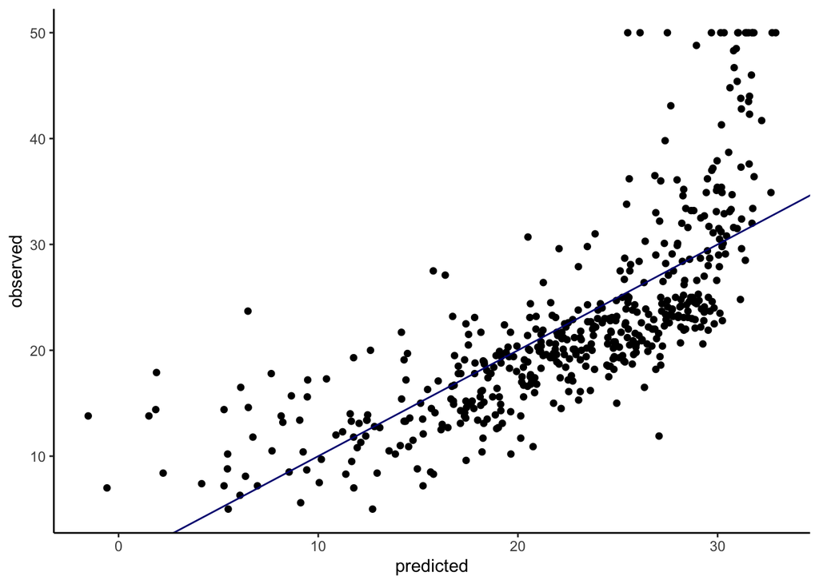

```r
data.frame(predicted = y_pred, observed = Boston$medv) %>%
  ggplot(aes(x = predicted, y = observed)) +
  geom_point()+
  geom_abline(slope=1, color="navy") + theme_classic()
```

## 6. Use the `seq()` function to generate a sequence of 1000 equally spaced values from 0 to 40. Store this vector in a data frame with (`data.frame()` or `tibble()`) as its column name `lstat`. Name the data frame `pred_dat`.

```r
pred_dat <- data.frame(lstat = seq(0, 40, length.out=1000))
```

## 7. Use the newly created data frame as the `newdata` argument to a `predict()` call for `lm_ses`. Store it in a variable named `y_pred_new`.

```r
y_pred_new <- predict(lm_ses, newdata = pred_dat)
```

# Plotting lm() in `ggplot`

## 8. Create a scatter plot from the `Boston` dataset with `lstat` mapped to the x position and `medv` mapped to the y position. Store the plot in an object called `p_scatter`.

```r
p_scatter <- Boston %>% ggplot(aes(x = lstat, y = medv)) +
  geom_point()
```

## 9. Add the vector `y_pred_new` to the `pred_dat` data frame with the name `medv`.

```r
pred_dat$medv <- y_pred_new
```

## 10. Add a geom_line() to `p_scatter`, with `pred_dat` as the `data` argument. What does this line represent?

This line represents the predicted `medv` value for the `lstat` ranging from 0 to 40.

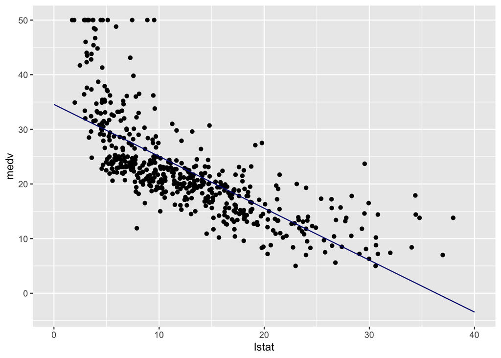

```r
p_scatter + geom_line(data = pred_dat, color="navy")
```

## 11. The `interval` argument can be used to generate confidence or prediction intervals. Create a new object called `y_pred_95` using `predict()` (again with the `pred_dat` data) with the `interval` argument set to “confidence”. What is in this object?

It contains the predicted values and lower & upper bound for the confidence interval.

```r
y_pred_95 <- predict(lm_ses, newdata = pred_dat, interval = "confidence")
```

## 12. Create a data frame with 4 columns: `medv`, `lstat`, `lower`, and `upper`.

```r
df <- cbind(pred_dat$lstat, y_pred_95) %>%
  as.data.frame() %>%
  rename(lstat = V1, medv = fit, lower = lwr, upper = upr)
```

## 13. Add a `geom_ribbon()` to the plot with the data frame you just made. The ribbon geom requires three aesthetics: `x` (`lstat`, already mapped), `ymin` (`lower`), and `ymax` (`upper`). Add the ribbon below the `geom_line()` and the `geom_points()` of before to make sure those remain visible. Give it a nice colour and clean up the plot, too!

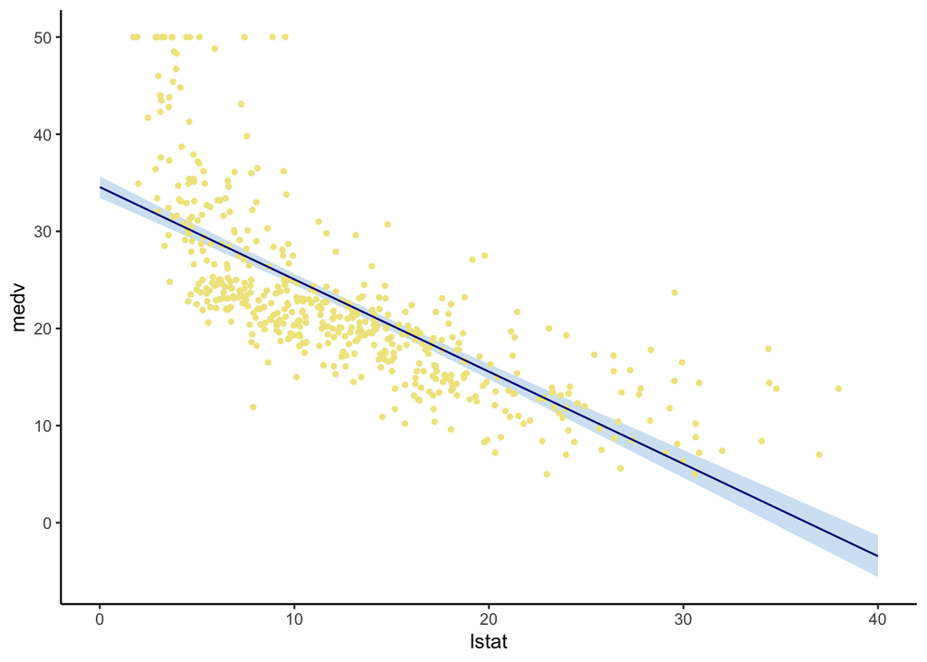

```r
Boston %>% ggplot(aes(x = lstat, y = medv)) +
  geom_ribbon(data = df, aes(ymin = lower, ymax = upper),  fill = alpha("#CFE2F3", 0.9)) +
  geom_point(color = "khaki", size=1) +
  geom_line(data = pred_dat, color="navy") +
  theme_classic()
```

## 14. Explain in your own words what the ribbon represents.

The ribbon represents the 95% confidence interval for the fitted values (i.e., blue line).

## 15. Do the same thing, but now with the prediction interval instead of the confidence interval.

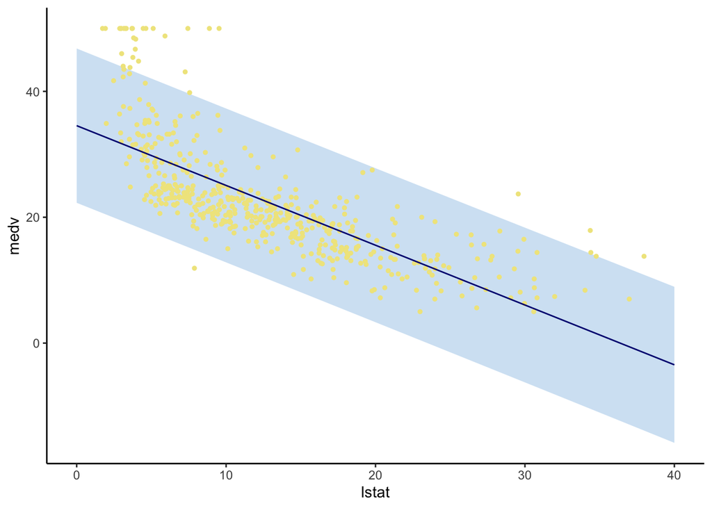

```r
y_pred_95 <- predict(lm_ses, newdata = pred_dat, interval = "prediction")

df <- cbind(pred_dat$lstat, y_pred_95) %>%
  as.data.frame() %>%
  rename(lstat = V1, medv = fit, lower = lwr, upper = upr)

Boston %>% ggplot(aes(x = lstat, y = medv)) +
  geom_ribbon(data = df, aes(ymin = lower, ymax = upper),  fill = alpha("#CFE2F3", 0.9)) +
  geom_point(color = "khaki", size=1) +
  geom_line(data = pred_dat, color="navy") +
  theme_classic()
```

# Mean square error

## 16. Write a function called `mse()` that takes in two vectors: true y values and predicted y values, and which outputs the mean square error.

```r
mse <- function(y_true, y_pred){
  mse = mean((y_true - y_pred)^2)
  return(MSE = mse)
}
```

## 17. Make sure your `mse()` function works correctly by running the following code.

```r
mse(1:10, 10:1)
```

```
[1] 33
```

## 18. Calculate the mean square error of the `lm_ses` model. Use the `medv` column as `y_true` and use the `predict()` method to generate `y_pred`.

```r
mse(Boston$medv, predict(lm_ses))
```

```
[1] 38.48297
```

# Train-validation-test split

## 19. The `Boston` dataset has 506 observations. Use `c()` and `rep()` to create a vector with 253 times the word “train”, 152 times the word “validation”, and 101 times the word “test”. Call this vector `splits`.

```r
splits <- c(rep("train", 253), rep("validation", 152), rep("test", 101))
```

## 20. Use the function `sample()` to randomly order this vector and add it to the `Boston` dataset using `mutate()`. Assign the newly created dataset to a variable called `boston_master`.

```r
boston_master <- Boston %>%
  mutate(groups = sample(splits))
```

## 21. Now use `filter()` to create a training, validation, and test set from the `boston_master` data. Call these datasets `boston_train`, `boston_valid`, and `boston_test`.

```r
dat <- boston_master %>%
  group_split(groups) %>%
  setNames(c("boston_test", "boston_train", "boston_valid"))
```

## 22. Train a linear regression model called `model_1` using the training dataset. Use the formula `medv ~ lstat` like in the first `lm()` exercise. Use `summary()` to check that this object is as you expect.

```r
model_1 <- lm(medv ~ lstat, data=dat$boston_train)
summary(model_1)
```

```
Call:
lm(formula = medv ~ lstat, data = dat$boston_train)

Residuals:
    Min      1Q  Median      3Q     Max
-10.513  -4.332  -1.379   1.680  23.893

Coefficients:
            Estimate Std. Error t value Pr(>|t|)
(Intercept)  35.8575     0.8489   42.24   <2e-16 ***
lstat        -1.0232     0.0590  -17.34   <2e-16 ***
---
Signif. codes:  0 '***' 0.001 '**' 0.01 '*' 0.05 '.' 0.1 ' ' 1

Residual standard error: 6.671 on 251 degrees of freedom
Multiple R-squared:  0.5451,    Adjusted R-squared:  0.5433
F-statistic: 300.7 on 1 and 251 DF,  p-value: < 2.2e-16
```

## 23. Calculate the MSE with this object. Save this value as `model_1_mse_train`.

```r
model_1_mse_train <- mse(dat$boston_train$medv, predict(model_1))
```

## 24. Now calculate the MSE on the validation set and assign it to variable `model_1_mse_valid`.

**Hint: use the `newdata` argument in `predict()`.**

```r
model_1_mse_valid <- mse(y_true = dat$boston_valid$medv, y_pred = predict(model_1, newdata = dat$boston_valid))
```

## 25. Create a second model `model_2` for the train data which includes `age` and `tax` as predictors. Calculate the train and validation MSE.

```r
model_2 <- lm(medv ~ lstat + age + tax, data=dat$boston_train)
model_2_mse_train <- mse(y_true = dat$boston_train$medv, y_pred = predict(model_2))
model_2_mse_valid <- mse(y_true = dat$boston_valid$medv, y_pred = predict(model_2, newdata = dat$boston_valid))
```

## 26. Compare model 1 and model 2 in terms of their training and validation MSE. Which would you choose and why?

```r
data.frame(M1_train = model_1_mse_train, M1_valid = model_1_mse_valid,
           M2_train = model_2_mse_train, M2_valid = model_2_mse_valid) %>%
  knitr::kable(digit=4, align='cccc', caption="Mean Square Error")
```

Mean Square Error

| M1_train | M1_valid | M2_train | M2_valid |
| --- | --- | --- | --- |
| 44.15 | 34.2214 | 40.8867 | 35.9536 |

## 27. Calculate the test MSE for the model of your choice in the previous question. What does this number tell you?

```r
model_2_mse_test <- mse(y_true = dat$boston_test$medv,
                        y_pred = predict(model_2, newdata = dat$boston_test))
```

# Programming exercise: cross-validation

## 28. Create a function that performs k-fold cross-validation for linear models.

**Inputs:**  
formula: a formula just as in the lm() function  
dataset: a data frame  
k: the number of folds for cross validation  
any other arguments you need necessary

**Outputs:**  
Mean square error averaged over folds

```r
#' @param formula formula goes in `lm()`
#' @param df the original data frame
#' @return Mean square error (MSE) averaged over folds

kf_cv <- function(formula, df, k,...){
  stopifnot(purrr::is_formula(formula))       # formula must be a formula
  stopifnot(is.data.frame(df))    # dataset must be data frame
  stopifnot(is.integer(as.integer(k))) # k must be convertible to int
  # first, add a selection column to the dataset
  select_vec <- rep(1:k, length.out = nrow(df))
  data_split <- df %>% mutate(folds = sample(select_vec))

  # initialize an output vector of k mse values, which we
  # will fill by using a _for loop_ going over each fold
  MSEs <- c()

  # start the for loop
  for (i in 1:k) {
    # split the data in train and validation set
    data_train <- data_split %>% filter(folds != i)
    data_valid <- data_split %>% filter(folds == i)

    # calculate the model on this data
    model_i <- lm(formula = formula, data = data_train)

    # Extract the y column name from the formula
    y_column_name <- as.character(formula)[2]

    # calculate the mean square error and assign it to MSEs
    MSEs[i] <- mse(y_true = data_valid[[y_column_name]],
                   y_pred = predict(model_i, newdata = data_valid))
  }
  return(mean(MSEs))
}
```

## 29. Use your function to perform 9-fold cross validation with a linear model with as its formula `medv ~ lstat + age + tax`. Compare it to a model with as formulat `medv ~ lstat + I(lstat^2) + age + tax`.

```r
kf_cv(formula = medv ~ lstat + age + tax, df = Boston, k = 9)
```

```
[1] 37.9243
```

```r
kf_cv(formula = medv ~ lstat + I(lstat^2) + age + tax, df = Boston, k = 9)
```

```
[1] 28.04979
```